# R Notebook

```r
# Create data directory if it doesn't exist
dir.create("data", showWarnings = FALSE)

# GSE205677 (NGT control + palmitate-treated dataset)
file_205677 <- "data/GSE205677_counts.tsv.gz"
url_205677  <- "https://ftp.ncbi.nlm.nih.gov/geo/series/GSE205nnn/GSE205677/suppl/GSE205677_counts.tsv.gz"

if (!file.exists(file_205677)) {
  download.file(url_205677, destfile = file_205677, mode = "wb")
}

# Verify file exists
file.exists(file_205677)
```

```
[1] TRUE
```

Data Created

```r
# Read raw count matrix (GSE205677)
counts <- read.table(
  "data/GSE205677_counts.tsv.gz",
  header = TRUE,
  row.names = 1,
  sep = "\t",
  check.names = FALSE
)

# Record dataset information
data <- list(
  data = counts,
  description = paste(
    "Raw bulk RNA-seq gene-level count matrix from GSE205677.",
    "Rows correspond to Ensembl gene identifiers.",
    "Columns correspond to individual RNA-seq libraries from",
    "primary human skeletal muscle myotubes with normal glucose tolerance (NGT).",
    "Samples include both control (NGT_CTL) and palmitate-treated (NGT_PAL)",
    "conditions, collected across multiple time points and biological replicates."
  ),
  processing = c(
    "RNA sequencing",
    "read alignment",
    "gene-level read counting"
  )
)

# dim check
dim(data$data)
```

```
[1] 16229   105
```

```r
# Inspect column headers
head(colnames(data$data), 10)
```

```
 [1] "NGT_CTL_12h_i01"
 [2] "NGT_CTL_18h_i01"
 [3] "NGT_CTL_30h_i01"
 [4] "NGT_CTL_36h_i01"
 [5] "NGT_CTL_42h_i01"
 [6] "NGT_CTL_48h_i01"
 [7] "NGT_CTL_54h_i01"
 [8] "NGT_PAL_12h_i01"
 [9] "NGT_PAL_18h_i01"
[10] "NGT_PAL_24h_i01"
```

```r
# Inspect first few rows of the count matrix
head(data$data, 5)
```

|  | NGT_CTL_12h_i01 | NGT_CTL_18h_i01 | NGT_CTL_30h_i01 | NGT_CTL_36h_i01 | NGT_CTL_42h_i01 | NGT_CTL_48h_i01 | NGT_CTL_54h_i01 | NGT_PAL_12h_i01 | NGT_PAL_18h_i01 | NGT_PAL_24h_i01 | NGT_PAL_30h_i01 | NGT_PAL_36h_i01 | NGT_PAL_42h_i01 | NGT_PAL_48h_i01 | NGT_PAL_54h_i01 | NGT_CTL_12h_i04 | NGT_CTL_18h_i04 | NGT_CTL_24h_i04 | NGT_CTL_30h_i04 | NGT_CTL_36h_i04 | NGT_CTL_42h_i04 | NGT_CTL_48h_i04 | NGT_CTL_54h_i04 | NGT_PAL_12h_i04 | NGT_PAL_18h_i04 | NGT_PAL_24h_i04 | NGT_PAL_30h_i04 | NGT_PAL_36h_i04 | NGT_PAL_42h_i04 | … |
| --- | --- | --- | --- | --- | --- | --- | --- | --- | --- | --- | --- | --- | --- | --- | --- | --- | --- | --- | --- | --- | --- | --- | --- | --- | --- | --- | --- | --- | --- | --- |
| ENSG00000227232 | 1 | 9 | 8 | 1 | 18 | 3 | 23 | 8 | 5 | 9 | 27 | 9 | 7 | 5 | 22 | 17 | 23 | 26 | 27 | 20 | 8 | 7 | 13 | 12 | 1 | 18 | 27 | 34 | 12 | … |
| ENSG00000279457 | 19 | 12 | 17 | 14 | 65 | 30 | 33 | 18 | 5 | 51 | 56 | 54 | 29 | 36 | 48 | 51 | 42 | 46 | 35 | 15 | 23 | 12 | 28 | 36 | 2 | 27 | 33 | 58 | 13 | … |
| ENSG00000237973 | 13 | 12 | 34 | 14 | 78 | 53 | 42 | 17 | 8 | 42 | 55 | 57 | 37 | 38 | 48 | 83 | 97 | 98 | 57 | 61 | 55 | 45 | 40 | 50 | 6 | 63 | 86 | 66 | 24 | … |
| ENSG00000248527 | 73 | 51 | 57 | 33 | 33 | 52 | 40 | 78 | 64 | 72 | 48 | 51 | 47 | 51 | 36 | 143 | 143 | 127 | 74 | 34 | 63 | 43 | 40 | 62 | 19 | 104 | 109 | 94 | 42 | … |
| ENSG00000228327 | 6 | 6 | 8 | 0 | 9 | 13 | 8 | 8 | 5 | 8 | 11 | 11 | 6 | 5 | 9 | 15 | 23 | 9 | 15 | 16 | 7 | 14 | 14 | 13 | 3 | 15 | 30 | 33 | 2 | … |

```r
# Record inspection step in processing history
data$processing <- c(
  data$processing,
  "inspection"
)

# View updated processing record
data$processing
```

```
[1] "RNA sequencing"
[2] "read alignment"
[3] "gene-level read counting"
[4] "inspection"
```

```r
# Extract sample names
samples <- colnames(data$data)

# Define condition based on column names
condition <- ifelse(grepl("_PAL_", samples), "Treatment", "Control")

table(condition)
```

```
condition
  Control Treatment
       53        52
```

```r
# Extract time point (e.g. 12h, 18h, ...)
timepoint <- sub(".*_([0-9]+h)_i[0-9]+$", "\\1", samples)

table(timepoint)
```

```
timepoint
12h 18h 24h 30h 36h 42h 48h 54h
 12  13  13  14  14  13  14  12
```

```r
table(condition, timepoint)
```

```
           timepoint
condition   12h 18h 24h 30h 36h 42h
  Control     7   6   6   7   7   6
  Treatment   5   7   7   7   7   7
           timepoint
condition   48h 54h
  Control     7   7
  Treatment   7   5
```

```r
# Total reads per sample
library_size <- colSums(data$data)

summary(library_size)
```

```
    Min.  1st Qu.   Median     Mean
 1528275 10172642 19278178 17977321
 3rd Qu.     Max.
23966538 44495793
```

```r
sample_info <- data.frame(
  sample     = samples,
  condition  = condition,
  timepoint  = timepoint,
  library_size = library_size,
  stringsAsFactors = FALSE
)

library_summary <- aggregate(
  library_size ~ condition + timepoint,
  data = sample_info,
  FUN = function(x) c(
    n = length(x),
    mean = mean(x),
    median = median(x),
    min = min(x),
    max = max(x)
  )
)
```

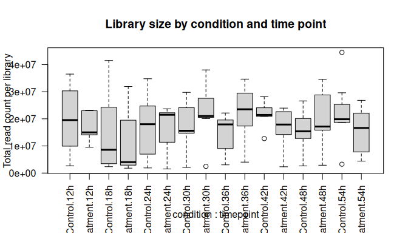

```r
boxplot(
  library_size ~ condition + timepoint,
  data = sample_info,
  las = 2,
  ylab = "Total read count per library",
  main = "Library size by condition and time point"
)
```

Figure X. Library size distribution across condition and time point

```r
library(biomaRt)
ensembl_version <- 115
ensembl <- useEnsembl(biomart = "ensembl",version = ensembl_version)
ensembl <- useDataset(
  "hsapiens_gene_ensembl",
  mart = ensembl
)
```

```
NA
```

```r
# Extract Ensembl gene IDs from count matrix
ensembl_ids <- rownames(data$data)

# Strip version suffix if present (safe even if none exist)
strip_ensembl_version <- function(x) sub("\\..*$", "", x)
ensembl_ids_clean <- strip_ensembl_version(ensembl_ids)

length(ensembl_ids_clean)
```

```
[1] 16229
```

```r
head(ensembl_ids_clean)
```

```
[1] "ENSG00000227232"
[2] "ENSG00000279457"
[3] "ENSG00000237973"
[4] "ENSG00000248527"
[5] "ENSG00000228327"
[6] "ENSG00000237491"
```

```r
gene_map <- getBM(
  attributes = c("ensembl_gene_id", "hgnc_symbol"),
  filters    = "ensembl_gene_id",
  values     = ensembl_ids_clean,
  mart       = ensembl
)

dim(gene_map)
```

```
[1] 16063     2
```

```r
head(gene_map)
```

|  | ensembl_gene_id | hgnc_symbol |
| --- | --- | --- |
| 1 | ENSG00000000457 | SCYL3 |
| 2 | ENSG00000000460 | FIRRM |
| 3 | ENSG00000000971 | CFH |
| 4 | ENSG00000001460 | STPG1 |
| 5 | ENSG00000001461 | NIPAL3 |
| 6 | ENSG00000001617 | SEMA3F |

```r
cache_file <- "data/ensembl_to_hgnc_map.rds"

if (!file.exists(cache_file)) {
  saveRDS(gene_map, cache_file)
} else {
  gene_map <- readRDS(cache_file)
}
```

```r
# Convert counts to data frame with gene IDs
counts_df <- as.data.frame(data$data)
counts_df$ensembl_gene_id <- ensembl_ids_clean
```

```r
ambiguous_ensembl <- gene_map %>%
  group_by(ensembl_gene_id) %>%
  summarise(n_symbols = n_distinct(hgnc_symbol)) %>%
  filter(n_symbols > 1)

ambiguous_ensembl
```

| ensembl_gene_id | n_symbols |
| --- | --- |
| ENSG00000230417 | 2 |

2Multiple Ensembl IDs mapping to the same symbol These will be kept sperate but given same symbol.

```r
multi_ensembl_per_symbol <- gene_map %>%
  filter(hgnc_symbol != "") %>%
  group_by(hgnc_symbol) %>%
  summarise(n_genes = n_distinct(ensembl_gene_id)) %>%
  filter(n_genes > 1)

multi_ensembl_per_symbol
```

| hgnc_symbol | n_genes |
| --- | --- |
| POLR2J3 | 2 |

```r
# Identify ambiguous Ensembl IDs
ambiguous_ids <- ambiguous_ensembl$ensembl_gene_id

# Clean gene_map
gene_map_clean <- gene_map %>%
  mutate(
    hgnc_symbol = ifelse(
      ensembl_gene_id %in% ambiguous_ids,
      NA,
      hgnc_symbol
    )
  ) %>%
  distinct(ensembl_gene_id, hgnc_symbol)

# Join HGNC symbols
counts_annotated <- counts_df %>%
  left_join(gene_map, by = "ensembl_gene_id")

# Reorder columns: annotation first
counts_annotated <- counts_annotated %>%
  relocate(ensembl_gene_id, hgnc_symbol)

# Record back into main data object
data$data <- counts_annotated

# Record processing step
data$processing <- c(
  data$processing,
  "Ensembl gene Mapping"
)

head(data$data[, 1:6])
```

|  | ensembl_gene_id | hgnc_symbol | NGT_CTL_12h_i01 | NGT_CTL_18h_i01 | NGT_CTL_30h_i01 | NGT_CTL_36h_i01 |
| --- | --- | --- | --- | --- | --- | --- |
| 1 | ENSG00000227232 | WASH7P | 1 | 9 | 8 | 1 |
| 2 | ENSG00000279457 | WASH9P | 19 | 12 | 17 | 14 |
| 3 | ENSG00000237973 | MTCO1P12 | 13 | 12 | 34 | 14 |
| 4 | ENSG00000248527 | MTATP6P1 | 73 | 51 | 57 | 33 |
| 5 | ENSG00000228327 |  | 6 | 6 | 8 | 0 |
| 6 | ENSG00000237491 | LINC01409 | 23 | 16 | 43 | 10 |

```r
# total genes symbols
table(!is.na(counts_annotated$hgnc_symbol))
```

```
FALSE  TRUE
  167 16063
```

```r
# duplicated symbols
sum(duplicated(counts_annotated$hgnc_symbol, na.rm = TRUE))
```

```
[1] 982
```

Given the robustness of downstream RNA-seq statistical methods to extreme values, no outlier removal was performed at this stage in the absence of independent evidence of technical failure.

Pre normalization

```r
# Identify count columns (exclude annotation)
count_cols <- !(colnames(data$data) %in% c("ensembl_gene_id", "hgnc_symbol"))

counts_mat <- as.matrix(data$data[, count_cols])

# Define filtering threshold
min_count   <- 10
min_samples <- 10

rownames(counts_mat) <- data$data$ensembl_gene_id

keep_genes <- rowSums(counts_mat >= min_count) >= min_samples

table(keep_genes)
```

```
keep_genes
 TRUE
16230
```

```r
# Filter the full data object (annotation + counts)
data$data_filtered <- data$data[keep_genes, ]

dim(data$data_filtered)
```

```
[1] 16230   107
```

```r
data$processing <- c(
  data$processing,
  paste0(
    "Low-count gene filtering: retained genes with ≥ ",
    min_count, " counts in ≥ ",
    min_samples, " samples"
  )
)

data$processing
```

```
[1] "RNA sequencing"
[2] "read alignment"
[3] "gene-level read counting"
[4] "inspection"
[5] "Ensembl gene Mapping"
[6] "Low-count gene filtering: retained genes with ≥ 10 counts in ≥ 10 samples"
```

Define plot functions:

```r
plot_box <- function(mat, main = "") {
  boxplot(
    log2(mat + 1),
    outline = FALSE,
    las = 2,
    main = main,
    ylab = "log2(count + 1)"
  )
}

plot_density <- function(mat, main = "") {
  mat <- log2(mat + 1)
  dens <- apply(mat, 2, density)

  plot(dens[[1]], col = "grey50", main = main, xlab = "log2(count + 1)")
  for (i in 2:length(dens)) {
    lines(dens[[i]], col = "grey50")
  }
}
```

Define time point grouping function:

```r
split_by_timepoint <- function(count_matrix, sample_names = colnames(count_matrix)) {

  # Extract time point from sample names (e.g. 12h, 18h, ...)
  timepoint <- sub(".*_([0-9]+h)_i[0-9]+$", "\\1", sample_names)

  # Split sample names by time point
  samples_by_tp <- split(sample_names, timepoint)

  # Create a list of sub-matrices
  count_by_tp <- lapply(samples_by_tp, function(samps) {
    count_matrix[, samps, drop = FALSE]
  })

  return(count_by_tp)
}
```

```r
inspect_timepoint_counts <- function(counts_by_tp) {
  for (tp in names(counts_by_tp)) {
    message("Inspecting time point: ", tp)

    mat <- counts_by_tp[[tp]]

    cat("Dimensions:", dim(mat), "\n")
    print(summary(as.vector(mat)))

    plot_box(mat, main = paste("Raw counts –", tp))
    plot_density(mat, main = paste("Raw counts density –", tp))
  }
}
```

```
Dimensions: 16230 12
   Min. 1st Qu.  Median    Mean
      0      36     202    1150
3rd Qu.    Max.
    775 1344105
```

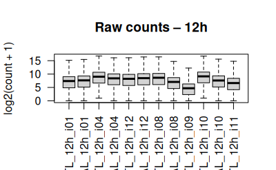

```
Dimensions: 16230 13
     Min.   1st Qu.    Median
      0.0      14.0      65.0
     Mean   3rd Qu.      Max.
    812.4     326.0 2203445.0
```

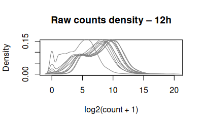

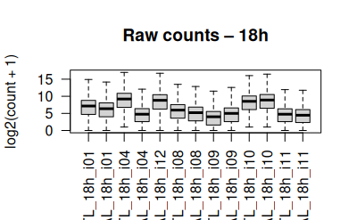

```
Dimensions: 16230 13
   Min. 1st Qu.  Median    Mean
      0      27     152    1035
3rd Qu.    Max.
    684 1338621
```

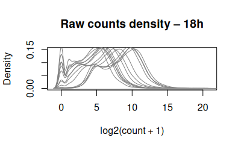

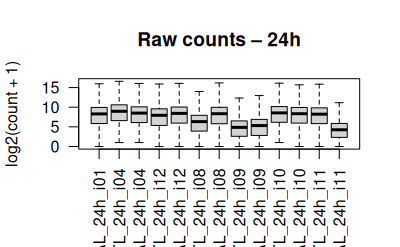

```
Dimensions: 16230 14
   Min. 1st Qu.  Median    Mean
      0      40     229    1246
3rd Qu.    Max.
    869 1848962
```

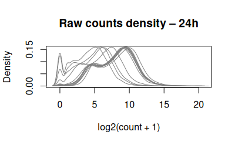

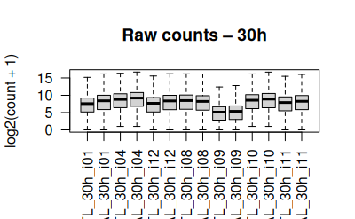

```
Dimensions: 16230 14
   Min. 1st Qu.  Median    Mean
      0      38     201    1128
3rd Qu.    Max.
    774 1790186
```

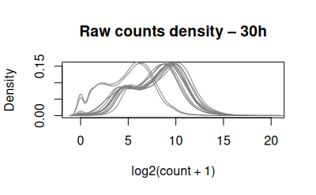

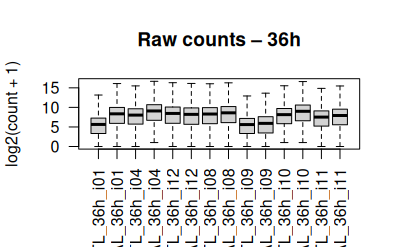

```
Dimensions: 16230 13
   Min. 1st Qu.  Median    Mean
      0      42     241    1169
3rd Qu.    Max.
    838 2043978
```

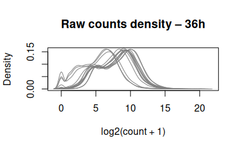

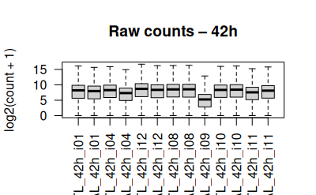

```
Dimensions: 16230 14
   Min. 1st Qu.  Median    Mean
      0      38     209    1119
3rd Qu.    Max.
    777 2105929
```

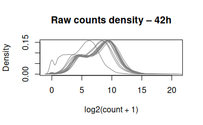

[4 more figures not shown]

```r
counts_raw <- as.matrix(data$data[, -c(1, 2)])
samples <- colnames(counts_raw)
counts_by_timepoint <- split_by_timepoint(counts_raw)
inspect_timepoint_counts(counts_by_timepoint)
```

Figure X. Distribution of raw gene expression counts across time points

Boxplots and density plots display the distribution of raw RNA-seq gene counts for samples grouped by circadian time point. Substantial variability in count distributions reflects differences in sequencing depth and library composition prior to normalization. The high proportion of low-count and zero-count genes motivates subsequent filtering and normalization steps.

```r
## ---- design-matrix-from-names ----

# Extract sample names
samples <- colnames(data$data)

# Build sample metadata directly from column names
sample_data <- data.frame(
  sample    = samples,
  treatment = sub(".*_(CTL|PAL)_.*", "\\1", samples),
  timepoint = sub(".*_([0-9]+h)_.*", "\\1", samples),
  replicate = sub(".*_(i[0-9]+)$", "\\1", samples),
  stringsAsFactors = FALSE
)

# Define biological condition: treatment × timepoint
sample_data$condition <- paste(
  sample_data$treatment,
  sample_data$timepoint,
  sep = "_"
)

# Inspect true sample sizes per condition
table(sample_data$condition)
```

```
                        CTL_12h
                              7
                        CTL_18h
                              6
                        CTL_24h
                              6
                        CTL_30h
                              7
                        CTL_36h
                              7
                        CTL_42h
                              6
                        CTL_48h
                              7
                        CTL_54h
                              7
ensembl_gene_id_ensembl_gene_id
                              1
        hgnc_symbol_hgnc_symbol
                              1
                        PAL_12h
                              5
                        PAL_18h
                              7
                        PAL_24h
                              7
                        PAL_30h
                              7
                        PAL_36h
                              7
                        PAL_42h
                              7
                        PAL_48h
                              7
                        PAL_54h
                              5
```

```r
# Construct design matrix
design <- model.matrix(~ 0 + condition, data = sample_data)
rownames(design) <- sample_data$sample
colnames(design) <- levels(factor(sample_data$condition))

# Inspect design matrix
head(design)
```

```
                CTL_12h CTL_18h
ensembl_gene_id       0       0
hgnc_symbol           0       0
NGT_CTL_12h_i01       1       0
NGT_CTL_18h_i01       0       1
NGT_CTL_30h_i01       0       0
NGT_CTL_36h_i01       0       0
                CTL_24h CTL_30h
ensembl_gene_id       0       0
hgnc_symbol           0       0
NGT_CTL_12h_i01       0       0
NGT_CTL_18h_i01       0       0
NGT_CTL_30h_i01       0       1
NGT_CTL_36h_i01       0       0
                CTL_36h CTL_42h
ensembl_gene_id       0       0
hgnc_symbol           0       0
NGT_CTL_12h_i01       0       0
NGT_CTL_18h_i01       0       0
NGT_CTL_30h_i01       0       0
NGT_CTL_36h_i01       1       0
                CTL_48h CTL_54h
ensembl_gene_id       0       0
hgnc_symbol           0       0
NGT_CTL_12h_i01       0       0
NGT_CTL_18h_i01       0       0
NGT_CTL_30h_i01       0       0
NGT_CTL_36h_i01       0       0
                ensembl_gene_id_ensembl_gene_id
ensembl_gene_id                               1
hgnc_symbol                                   0
NGT_CTL_12h_i01                               0
NGT_CTL_18h_i01                               0
NGT_CTL_30h_i01                               0
NGT_CTL_36h_i01                               0
                hgnc_symbol_hgnc_symbol
ensembl_gene_id                       0
hgnc_symbol                           1
NGT_CTL_12h_i01                       0
NGT_CTL_18h_i01                       0
```

[output cut: 15 more lines]

```
NGT_CTL_36h_i01       0       0
                PAL_36h PAL_42h
ensembl_gene_id       0       0
hgnc_symbol           0       0
NGT_CTL_12h_i01       0       0
NGT_CTL_18h_i01       0       0
NGT_CTL_30h_i01       0       0
NGT_CTL_36h_i01       0       0
                PAL_48h PAL_54h
ensembl_gene_id       0       0
hgnc_symbol           0       0
NGT_CTL_12h_i01       0       0
NGT_CTL_18h_i01       0       0
NGT_CTL_30h_i01       0       0
NGT_CTL_36h_i01       0       0
```

```r
## ---- prepare-filtered-counts ----

count_cols <- !(colnames(data$data_filtered) %in% c("ensembl_gene_id", "hgnc_symbol"))

counts_filtered <- as.matrix(
  data$data_filtered[, count_cols]
)

storage.mode(counts_filtered) <- "integer"

dim(counts_filtered)
```

```
[1] 16230   105
```

```r
library(edgeR)

dge <- DGEList(counts = counts_filtered)

keep <- filterByExpr(
  dge,
  design = design,
  min.count = 10
)

table(keep)
```

```
keep
 TRUE
16230
```

```r
dge_filtered <- dge[keep, , keep.lib.sizes = FALSE]

dim(dge_filtered)
```

```
[1] 16230   105
```

```r
dge_filtered <- calcNormFactors(dge_filtered, method = "TMM")

dge_filtered$samples
```

|  | group | lib.size | norm.factors |
| --- | --- | --- | --- |
| NGT_CTL_12h_i01 | 1 | 12579412 | 0.9401901 |
| NGT_CTL_18h_i01 | 1 | 11604458 | 0.8762113 |
| NGT_CTL_30h_i01 | 1 | 14018300 | 0.9742833 |
| NGT_CTL_36h_i01 | 1 | 6284707 | 0.5663289 |
| NGT_CTL_42h_i01 | 1 | 21050408 | 0.9677165 |
| NGT_CTL_48h_i01 | 1 | 22118180 | 0.9921210 |
| NGT_CTL_54h_i01 | 1 | 21015590 | 1.0150009 |
| NGT_PAL_12h_i01 | 1 | 15001968 | 0.9486170 |
| NGT_PAL_18h_i01 | 1 | 9378934 | 0.6510577 |
| NGT_PAL_24h_i01 | 1 | 22413991 | 0.9893454 |

[output cut: 95 more lines]

```r
norm_cpm <- cpm(
  dge_filtered,
  log = FALSE,
  prior.count = 1
)

dim(norm_cpm)
```

```
[1] 16230   105
```

```
Dimensions: 16230 12
     Min.   1st Qu.    Median
     0.00      2.42     13.75
     Mean   3rd Qu.      Max.
    61.81     43.83 414111.00
```

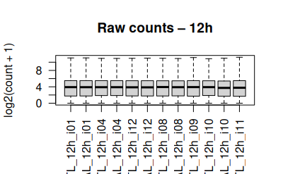

```
Dimensions: 16230 13
     Min.   1st Qu.    Median
     0.00      2.57     14.08
     Mean   3rd Qu.      Max.
    83.50     43.75 846902.01
```

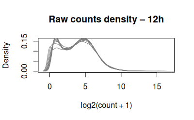

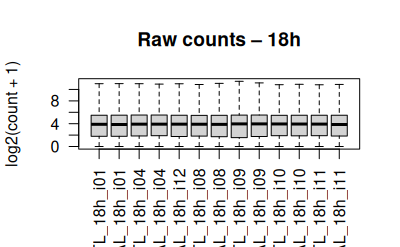

```
Dimensions: 16230 13
     Min.   1st Qu.    Median
0.000e+00 2.525e+00 1.427e+01
     Mean   3rd Qu.      Max.
6.096e+01 4.416e+01 2.362e+05
```

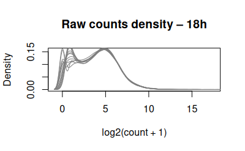

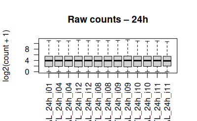

```
Dimensions: 16230 14
    Min.  1st Qu.   Median     Mean
    0.00     2.56    14.27    58.57
 3rd Qu.     Max.
   43.87 99541.71
```

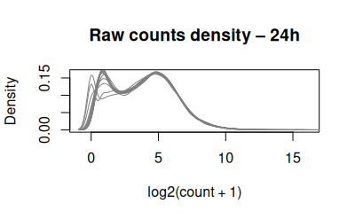

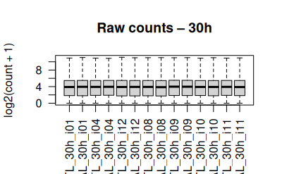

```
Dimensions: 16230 14
     Min.   1st Qu.    Median
     0.00      2.56     14.08
     Mean   3rd Qu.      Max.
    60.89     43.48 502972.68
```

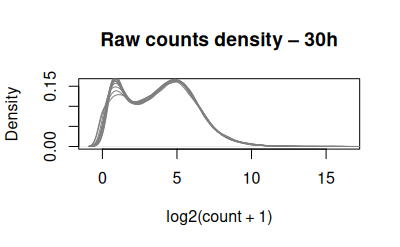

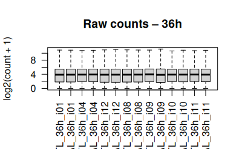

```
Dimensions: 16230 13
     Min.   1st Qu.    Median
    0.000     2.502    14.178
     Mean   3rd Qu.      Max.
   59.051    44.039 68118.402
```

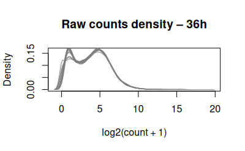

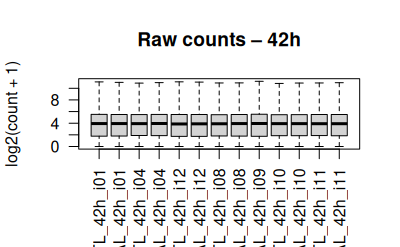

```
Dimensions: 16230 14
     Min.   1st Qu.    Median
0.000e+00 2.514e+00 1.424e+01
     Mean   3rd Qu.      Max.
5.864e+01 4.406e+01 1.191e+05
```

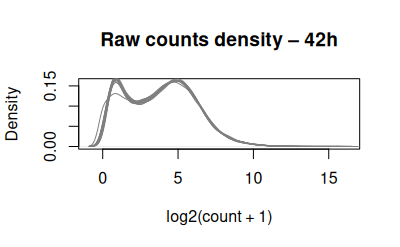

[4 more figures not shown]

```r
## ---- post-qc-timepoint-inspection-normalized ----

# Use normalized CPM matrix instead of raw counts
counts_norm <- norm_cpm

# Confirm sample names
samples <- colnames(counts_norm)

# Split normalized counts by timepoint
counts_by_timepoint <- split_by_timepoint(counts_norm)

# Inspect per-timepoint distributions (boxplots / density)
inspect_timepoint_counts(counts_by_timepoint)
```

Figure X. Distribution of normalized gene expression across time points

Boxplots and density plots show the distribution of normalized expression values (CPM) for each circadian time point. Normalization reduces library size–driven differences and yields comparable expression distributions across samples and time points. The consistency of distributions indicates successful normalization and suggests that remaining variation reflects biological effects rather than technical artifacts.

```r
library(RColorBrewer)
## ---- align-metadata ----

# Extract sample names actually present in dge_filtered
dge_samples <- colnames(dge_filtered)

# Reorder and subset metadata
meta <- sample_data[match(dge_samples, sample_data$sample), ]
```

MDS 1 — colored by treatment (CTL vs PAL)

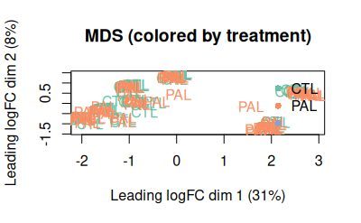

```r
treatment_cols <- brewer.pal(
  length(unique(meta$treatment)),
  "Set2"
)
names(treatment_cols) <- unique(meta$treatment)

plotMDS(
  dge_filtered,
  col = treatment_cols[meta$treatment],
  labels = meta$treatment,
  main = "MDS (colored by treatment)"
)

legend(
  "topright",
  legend = names(treatment_cols),
  col = treatment_cols,
  pch = 16,
  bty = "n"
)
```

Figure X. Multidimensional scaling (MDS) plot colored by treatment

MDS 2 — colored by timepoint

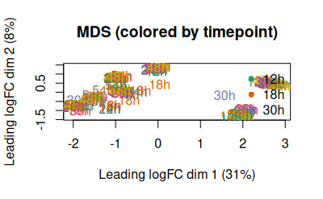

```r
time_cols <- colorRampPalette(brewer.pal(8, "Dark2"))(
  length(unique(meta$timepoint))
)
names(time_cols) <- unique(meta$timepoint)

plotMDS(
  dge_filtered,
  col = time_cols[meta$timepoint],
  labels = meta$timepoint,
  main = "MDS (colored by timepoint)"
)

legend(
  "topright",
  legend = names(time_cols),
  col = time_cols,
  pch = 16,
  bty = "n"
)
```

Figure Y. Multidimensional scaling (MDS) plot colored by time point

MDS 3 — colored by biological replicate (i0x)

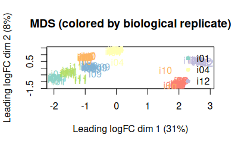

```r
rep_cols <- brewer.pal(
  length(unique(meta$replicate)),
  "Set3"
)
names(rep_cols) <- unique(meta$replicate)

plotMDS(
  dge_filtered,
  col = rep_cols[meta$replicate],
  labels = meta$replicate,
  main = "MDS (colored by biological replicate)"
)

legend(
  "topright",
  legend = names(rep_cols),
  col = rep_cols,
  pch = 16,
  bty = "n"
)
```

Figure Z. Multidimensional scaling (MDS) plot colored by biological replicate

```r
## ---- save-qc-objects ----

saveRDS(
  list(
    dge_filtered = dge_filtered,
    meta         = meta,
    design       = design,
    norm_cpm     = norm_cpm,
    mappings     = gene_map
  ),
  file = "data/d1_qc_objects.rds"
)
```

```r
obj <- readRDS("data/d1_qc_objects.rds")

dge <- obj$dge_filtered
meta <- obj$meta
mappings <- obj$mappings
```

Recreate design matrix and factors

```r
meta$timepoint <- factor(meta$timepoint)
meta$treatment <- factor(meta$treatment, levels = c("CTL", "PAL"))
design <- model.matrix(~ timepoint + treatment, data = meta)
colnames(design)
```

```
[1] "(Intercept)"  "timepoint18h"
[3] "timepoint24h" "timepoint30h"
[5] "timepoint36h" "timepoint42h"
[7] "timepoint48h" "timepoint54h"
[9] "treatmentPAL"
```

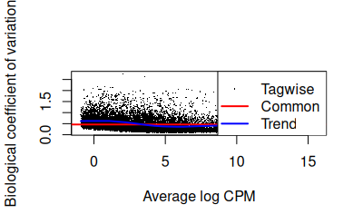

```r
dge <- estimateDisp(dge, design)

fit <- glmQLFit(dge, design)

plotBCV(dge)
```

Figure X. Biological Coefficient of Variation (BCV) plot

The BCV plot shows gene-wise biological variability as a function of average expression. Lowly expressed genes exhibit higher relative variability, while dispersion stabilizes for more highly expressed genes. The smooth trend indicates successful dispersion estimation, supporting the use of edgeR quasi-likelihood testing for differential expression analysis.

Hypothesis testing

```r
qlf_pal_vs_ctl <- glmQLFTest(
  fit,
  coef = "treatmentPAL"
)
topTags(qlf_pal_vs_ctl)
```

```
Coefficient:  treatmentPAL
```

|  | logFC | logCPM | F | PValue | FDR |
| --- | --- | --- | --- | --- | --- |
| 14751 | 1.9734157 | 5.897820 | 137.60501 | 1.911157e-20 | 3.101808e-16 |
| 9117 | 0.6889545 | 4.675120 | 109.68699 | 1.009674e-17 | 8.193506e-14 |
| 6333 | 1.8564969 | 5.005888 | 64.40425 | 2.114638e-12 | 1.144019e-08 |
| 2645 | 0.6178718 | 7.760994 | 58.14521 | 1.498943e-11 | 6.081963e-08 |
| 8798 | 1.1060848 | 7.323202 | 55.79662 | 3.199997e-11 | 1.038719e-07 |
| 9803 | 1.3573818 | 8.769589 | 48.96817 | 3.111944e-10 | 8.417809e-07 |
| 7859 | 1.3442054 | 8.636022 | 47.92345 | 4.450411e-10 | 1.031860e-06 |
| 1680 | 0.5003193 | 3.901985 | 44.08804 | 1.703516e-09 | 2.879579e-06 |
| 6464 | 0.7326566 | 5.688206 | 44.03840 | 1.725381e-09 | 2.879579e-06 |
| 6681 | 0.7236491 | 7.461913 | 43.95778 | 1.774232e-09 | 2.879579e-06 |

```r
res_pal <- topTags(qlf_pal_vs_ctl, n = Inf)$table %>%
  tibble::rownames_to_column("ensembl")
```

```r
sum(res_pal$PValue < 0.05)
```

```
[1] 1223
```

```r
sig_res <- res_pal %>%
  filter(FDR < 0.05, abs(logFC) >= 1)

nrow(sig_res)
```

```
[1] 14
```

p-value correction: Benjamini–Hochberg FDR

Controls false discovery rate under thousands of tests (standard for RNA-seq)

Effect size filter: |log2FC| ≥ 1 to exclude biologically trivial changes

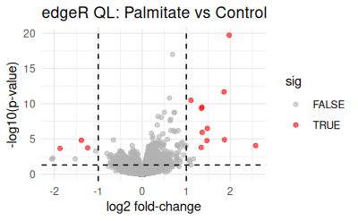

```r
library(ggplot2)

volcano_df <- res_pal %>%
  mutate(
    sig = FDR < 0.05 & abs(logFC) >= 1
  )

ggplot(volcano_df, aes(logFC, -log10(PValue))) +
  geom_point(aes(color = sig), alpha = 0.6) +
  scale_color_manual(values = c("grey70", "red")) +
  geom_vline(xintercept = c(-1, 1), linetype = "dashed") +
  geom_hline(yintercept = -log10(0.05), linetype = "dashed") +
  theme_minimal() +
  labs(
    title = "edgeR QL: Palmitate vs Control",
    x = "log2 fold-change",
    y = "-log10(p-value)"
  )
```

```r
map_df <- mappings %>%
  transmute(
    ensembl = as.character(ensembl_gene_id),
    symbol  = as.character(hgnc_symbol)
  ) %>%
  distinct(ensembl, .keep_all = TRUE)

sig_res_annot <- sig_res %>%
  left_join(map_df, by = c("ensembl" = "ensembl")) %>%
  mutate(label = ifelse(is.na(symbol) | symbol == "", ensembl, symbol))
```

```r
logcpm <- cpm(dge, log = TRUE, prior.count = 1)

hm <- logcpm[sig_res_annot$ensembl, ]
rownames(hm) <- make.unique(sig_res_annot$label)

hm_z <- t(scale(t(hm)))
```

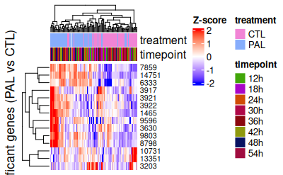

```r
library(ComplexHeatmap)
library(circlize)

ha <- HeatmapAnnotation(
  treatment = meta$treatment,
  timepoint = meta$timepoint
)

Heatmap(
  hm_z,
  name = "Z-score",
  top_annotation = ha,
  col = colorRamp2(c(-2, 0, 2), c("blue", "white", "red")),
  show_row_names = TRUE,
  row_names_gp = grid::gpar(fontsize = 8),
  show_column_names = FALSE,
  cluster_rows = TRUE,
  cluster_columns = TRUE,
  row_title = "Significant genes (PAL vs CTL)"
)
```